# Introduction to the taxa package

Scott Chamberlain and Zachary Foster

2017-12-18

`taxa` defines taxonomic classes and functions to manipulate them. The goal is to use these classes as low level fundamental taxonomic classes that other R packages can build on and use.

There are two distinct types of classes in `taxa`:

- Classes that are concerned only with taxonomic information: `taxon`, `taxonomy`, `hierarchy`, etc.
- A class called `taxmap` that is concerned with combining taxonomic data with user-defined data of any type (e.g. molecular sequences, abundance counts etc.)

Diagram of class concepts for `taxa` classes:

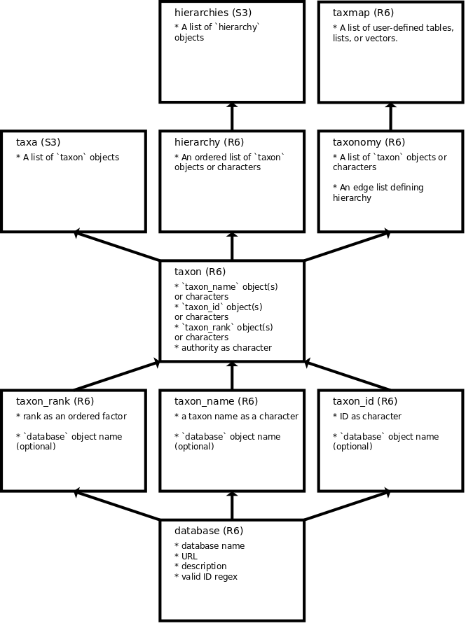

## Install

CRAN version

```r
install.packages("taxa")
```

Development version from GitHub

```r
devtools::install_github("ropensci/taxa")
```

```r
library("taxa")
```

## The classes

### Minor component classes

There are a few optional classes used to store information in other classes. In most cases, these can be replaced with simple character values but using them provides more information and potential functionality.

#### database

Taxonomic data usually comes from a database. A common example is the [NCBI Taxonomy Database](https://www.ncbi.nlm.nih.gov/taxonomy) used to provide taxonomic classifications to sequences deposited in [other NCBI databases](https://www.ncbi.nlm.nih.gov/guide/all/). The `database` class stores the name of the database and associated information:

```r
(ncbi <- taxon_database(
  name = "ncbi",
  url = "http://www.ncbi.nlm.nih.gov/taxonomy",
  description = "NCBI Taxonomy Database",
  id_regex = "*"
))
```

```
#> <database> ncbi
#>   url: http://www.ncbi.nlm.nih.gov/taxonomy
#>   description: NCBI Taxonomy Database
#>   id regex: *
```

```r
ncbi$name
```

```
#> [1] "ncbi"
```

```r
ncbi$url
```

```
#> [1] "http://www.ncbi.nlm.nih.gov/taxonomy"
```

To save on memory, a selection of common databases is provided with the package (`database_list`) and any in this list can be used by name instead of making a new database object (e.g. `"ncbi"` instead of the `ncbi` above).

```r
database_list
```

```
#> $ncbi
#> <database> ncbi
#>   url: http://www.ncbi.nlm.nih.gov/taxonomy
#>   description: NCBI Taxonomy Database
#>   id regex: .*
#>
#> $gbif
#> <database> gbif
#>   url: http://www.gbif.org/developer/species
#>   description: GBIF Taxonomic Backbone
#>   id regex: .*
#>
#> $bold
#> <database> bold
#>   url: http://www.boldsystems.org
#>   description: Barcode of Life
#>   id regex: .*
#>
#> $col
#> <database> col
#>   url: http://www.catalogueoflife.org
#>   description: Catalogue of Life
#>   id regex: .*
#>
#> $eol
#> <database> eol
#>   url: http://eol.org
#>   description: Encyclopedia of Life
#>   id regex: .*
#>
#> $nbn
#> <database> nbn
#>   url: https://nbn.org.uk
#>   description: UK National Biodiversity Network
#>   id regex: .*
#>
#> $tps
#> <database> tps
#>   url: http://www.tropicos.org/
#>   description: Tropicos
#>   id regex: .*
#>
#> $itis
#> <database> itis
#>   url: http://www.itis.gov
#>   description: Integrated Taxonomic Information System
#>   id regex: .*
```

#### rank

Taxa might have defined ranks (e.g. species, family, etc.), ambiguous ranks (e.g. “unranked”, “unknown”), or no rank information at all. The particular selection and format of valid ranks varies with database, so the database can be optionally defined. If no database is defined, any ranks in any order are allowed.

```r
taxon_rank(name = "species", database = "ncbi")
```

```
#> <TaxonRank> species
#>   database: ncbi
```

#### `taxon_name`

The taxon name can be defined in the same way as rank.

```r
taxon_name("Poa", database = "ncbi")
```

```
#> <TaxonName> Poa
#>   database: ncbi
```

#### taxon_id

Each database has its set of unique taxon IDs. These IDs are better than using the taxon name directly because they are guaranteed to be unique, whereas there are often duplicates of taxon names (e.g. *Orestias elegans* is the name of both an orchid and a fish).

```r
taxon_id(12345, database = "ncbi")
```

```
#> <TaxonId> 12345
#>   database: ncbi
```

### The “taxon” class

The `taxon` class combines the classes containing the name, rank, and ID for the taxon. There is also a place to define an authority of the taxon.

```r
(x <- taxon(
  name = taxon_name("Poa annua"),
  rank = taxon_rank("species"),
  id = taxon_id(93036),
  authority = "Linnaeus"
))
```

```
#> <Taxon>
#>   name: Poa annua
#>   rank: species
#>   id: 93036
#>   authority: none
```

Instead of the name, rank, and ID classes, simple character vectors can be supplied.

```r
(x <- taxon(
  name = "Poa annua",
  rank = "species",
  id = 93036,
  authority = "Linnaeus"
))
```

```
#> <Taxon>
#>   name: Poa annua
#>   rank: species
#>   id: 93036
#>   authority: none
```

The `taxa` class is just a list of `taxon` classes with some custom print methods. It is meant to store an arbitrary list of `taxon`.

```r
(x <- taxon(
  name = taxon_name("Poa annua"),
  rank = taxon_rank("species"),
  id = taxon_id(93036)
))
```

```
#> <Taxon>
#>   name: Poa annua
#>   rank: species
#>   id: 93036
#>   authority: none
```

```r
taxa(x, x, x)
```

```
#> <taxa>
#>   no. taxa:  3
#>   Poa annua / species / 93036
#>   Poa annua / species / 93036
#>   Poa annua / species / 93036
```

### The “hierarchy” class

Taxonomic classifications are an ordered set of taxa, each at a different rank. The `hierarchy` class stores a list of `taxon` classes like `taxa`, but `hierarchy` is meant to store all of the taxa in a classification in the correct order.

```r
x <- taxon(
  name = taxon_name("Poaceae"),
  rank = taxon_rank("family"),
  id = taxon_id(4479)
)

y <- taxon(
  name = taxon_name("Poa"),
  rank = taxon_rank("genus"),
  id = taxon_id(4544)
)

z <- taxon(
  name = taxon_name("Poa annua"),
  rank = taxon_rank("species"),
  id = taxon_id(93036)
)

(hier1 <- hierarchy(z, y, x))
```

```
#> <Hierarchy>
#>   no. taxon's:  3
#>   Poaceae / family / 4479
#>   Poa / genus / 4544
#>   Poa annua / species / 93036
```

Multiple `hierarchy` classes are stored in the `hierarchies` class, similar to how multiple `taxon` are stored in `taxa`.

```r
a <- taxon(
  name = taxon_name("Felidae"),
  rank = taxon_rank("family"),
  id = taxon_id(9681)
)
b <- taxon(
  name = taxon_name("Puma"),
  rank = taxon_rank("genus"),
  id = taxon_id(146712)
)
c <- taxon(
  name = taxon_name("Puma concolor"),
  rank = taxon_rank("species"),
  id = taxon_id(9696)
)
(hier2 <- hierarchy(c, b, a))
```

```
#> <Hierarchy>
#>   no. taxon's:  3
#>   Felidae / family / 9681
#>   Puma / genus / 146712
#>   Puma concolor / species / 9696
```

```r
hierarchies(hier1, hier2)
```

```
#> <Hierarchies>
#>   no. hierarchies:  2
#>   Poaceae / Poa / Poa annua
#>   Felidae / Puma / Puma concolor
```

### The “taxonomy” class

The `taxonomy` class stores unique `taxon` objects in a tree structure. Usually this kind of complex information would be the output of a file parsing function, but the code below shows how to construct a `taxonomy` object from scratch.

```r
# define taxa
notoryctidae <- taxon(name = "Notoryctidae", rank = "family", id = 4479)
notoryctes <- taxon(name = "Notoryctes", rank = "genus", id = 4544)
typhlops <- taxon(name = "typhlops", rank = "species", id = 93036)
mammalia <- taxon(name = "Mammalia", rank = "class", id = 9681)
felidae <- taxon(name = "Felidae", rank = "family", id = 9681)
felis <- taxon(name = "Felis", rank = "genus", id = 9682)
catus <- taxon(name = "catus", rank = "species", id = 9685)
panthera <- taxon(name = "Panthera", rank = "genus", id = 146712)
tigris <- taxon(name = "tigris", rank = "species", id = 9696)
plantae <- taxon(name = "Plantae", rank = "kingdom", id = 33090)
solanaceae <- taxon(name = "Solanaceae", rank = "family", id = 4070)
solanum <- taxon(name = "Solanum", rank = "genus", id = 4107)
lycopersicum <- taxon(name = "lycopersicum", rank = "species", id = 49274)
tuberosum <- taxon(name = "tuberosum", rank = "species", id = 4113)
homo <- taxon(name = "homo", rank = "genus", id = 9605)
sapiens <- taxon(name = "sapiens", rank = "species", id = 9606)
hominidae <- taxon(name = "Hominidae", rank = "family", id = 9604)

# define hierarchies
tiger <- hierarchy(mammalia, felidae, panthera, tigris)
cat <- hierarchy(mammalia, felidae, felis, catus)
human <- hierarchy(mammalia, hominidae, homo, sapiens)
mole <- hierarchy(mammalia, notoryctidae, notoryctes, typhlops)
tomato <- hierarchy(plantae, solanaceae, solanum, lycopersicum)
potato <- hierarchy(plantae, solanaceae, solanum, tuberosum)

# make taxonomy
(tax <- taxonomy(tiger, cat, human, tomato, potato))
```

```
#> <Taxonomy>
#>   14 taxa: b. Mammalia ... n. lycopersicum, o. tuberosum
#>   14 edges: NA->b, NA->c, b->d ... h->l, i->m, j->n, j->o
```

Unlike the `hierarchies` class, each unique `taxon` object is only represented once in the `taxonomy` object. Each taxon has a corresponding entry in an [edge list](https://en.wikipedia.org/wiki/Adjacency_list) that encode how it is related to other taxa. This makes `taxonomy` more compact, but harder to manipulate using standard indexing. To make manipulation easier, there are methods for `taxomomy` that can provide indexes in a taxonomic context.

#### supertaxa

A “supertaxon” is a taxon of a coarser rank that encompasses the taxon of interest (e.g. “Homo” is a supertaxon of “sapiens”). The `supertaxa` function returns the supertaxa of all or a subset of the taxa in a `taxonomy` object.

```r
supertaxa(tax)
```

```
#> $b
#> integer(0)
#>
#> $c
#> integer(0)
#>
#> $d
#> [1] 1
#>
#> $e
#> [1] 1
#>
#> $f
#> [1] 2
#>
#> $g
#> [1] 3 1
#>
#> $h
#> [1] 3 1
#>
#> $i
#> [1] 4 1
#>
#> $j
#> [1] 5 2
#>
#> $k
#> [1] 6 3 1
#>
#> $l
#> [1] 7 3 1
#>
#> $m
#> [1] 8 4 1
#>
#> $n
#> [1] 9 5 2
#>
#> $o
#> [1] 9 5 2
```

By default, the taxon IDs for the supertaxa of all taxa are returned in the same order they appear in the edge list. Taxon IDs (character) or edge list indexes (integer) can be supplied to the `subset` option to only return information for some taxa.

```r
supertaxa(tax, subset = "m")
```

```
#> $m
#> [1] 8 4 1
```

What is returned can be modified with the `value` option:

```r
supertaxa(tax, subset = "m", value = "taxon_names")
```

```
#> $m
#>           i           e           b
#>      "homo" "Hominidae"  "Mammalia"
```

```r
supertaxa(tax, subset = "m", value = "taxon_ranks")
```

```
#> $m
#>        i        e        b
#>  "genus" "family"  "class"
```

You can also subset based on a logical test:

```r
supertaxa(tax, subset = taxon_ranks == "genus", value = "taxon_names")
```

```
#> $g
#>          d          b
#>  "Felidae" "Mammalia"
#>
#> $h
#>          d          b
#>  "Felidae" "Mammalia"
#>
#> $i
#>           e           b
#> "Hominidae"  "Mammalia"
#>
#> $j
#>            f            c
#> "Solanaceae"    "Plantae"
```

The `subset` and `value` work the same for most of the following functions as well. See `tax$all_names()` for what can be used with `value`.

#### subtaxa

The “subtaxa” of a taxon are all those of a finer rank encompassed by that taxon. For example, *sapiens* is a subtaxon of *Homo*. The `subtaxa` function returns all subtaxa for each taxon in a `taxonomy` object.

```r
subtaxa(tax, value = "taxon_names")
```

```
#> $b
#>           d           g           k           h           l           e
#>   "Felidae"  "Panthera"    "tigris"     "Felis"     "catus" "Hominidae"
#>           i           m
#>      "homo"   "sapiens"
#>
#> $c
#>              f              j              n              o
#>   "Solanaceae"      "Solanum" "lycopersicum"    "tuberosum"
#>
#> $d
#>          g          k          h          l
#> "Panthera"   "tigris"    "Felis"    "catus"
#>
#> $e
#>         i         m
#>    "homo" "sapiens"
#>
#> $f
#>              j              n              o
#>      "Solanum" "lycopersicum"    "tuberosum"
#>
#> $g
#>        k
#> "tigris"
#>
#> $h
#>       l
#> "catus"
#>
#> $i
#>         m
#> "sapiens"
#>
#> $j
#>              n              o
#> "lycopersicum"    "tuberosum"
#>
#> $k
#> named character(0)
#>
#> $l
#> named character(0)
#>
#> $m
#> named character(0)
#>
#> $n
#> named character(0)
#>
#> $o
#> named character(0)
```

#### roots

We call taxa that have no supertaxa “roots”. The `roots` function returns these taxa.

```r
roots(tax, value = "taxon_names")
```

```
#>          b          c
#> "Mammalia"  "Plantae"
```

#### leaves

We call taxa without any subtaxa “leaves”. The `leaves` function returns these taxa.

```r
leaves(tax, value = "taxon_names")
```

```
#>              k              l              m              n              o
#>       "tigris"        "catus"      "sapiens" "lycopersicum"    "tuberosum"
```

#### other functions

There are many other functions to interact with `taxonomy` object, such as `stems` and `n_subtaxa`, but these will not be described here for now.

### The “taxmap” class

The `taxmap` class is used to store any number of tables, lists, or vectors associated with taxa. It is basically the same as the `taxonomy` class, but with the following additions:

- A list called `data` that stores arbitrary user data associated with taxa
- A list called `funcs` that stores user defined functions

```r
info <- data.frame(name = c("tiger", "cat", "mole", "human", "tomato", "potato"),
                   n_legs = c(4, 4, 4, 2, 0, 0),
                   dangerous = c(TRUE, FALSE, FALSE, TRUE, FALSE, FALSE))

phylopic_ids <- c("e148eabb-f138-43c6-b1e4-5cda2180485a",
                  "12899ba0-9923-4feb-a7f9-758c3c7d5e13",
                  "11b783d5-af1c-4f4e-8ab5-a51470652b47",
                  "9fae30cd-fb59-4a81-a39c-e1826a35f612",
                  "b6400f39-345a-4711-ab4f-92fd4e22cb1a",
                  "63604565-0406-460b-8cb8-1abe954b3f3a")

foods <- list(c("mammals", "birds"),
              c("cat food", "mice"),
              c("insects"),
              c("Most things, but especially anything rare or expensive"),
              c("light", "dirt"),
              c("light", "dirt"))

reaction <- function(x) {
  ifelse(x$data$info$dangerous,
         paste0("Watch out! That ", x$data$info$name, " might attack!"),
         paste0("No worries; its just a ", x$data$info$name, "."))
}

my_taxmap <- taxmap(tiger, cat, mole, human, tomato, potato,
                    data = list(info = info,
                                phylopic_ids = phylopic_ids,
                                foods = foods),
                    funcs = list(reaction = reaction))
```

In most functions that work with taxmap objects, the names of list/vector datasets, table columns, or functions can be used as if they were separate variables on their own. In the case of functions, instead of returning the function itself, the results of the functions are returned. To see what variables can be used this way, use `all_names`.

```r
all_names(my_taxmap)
```

```
#>         taxon_names           taxon_ids       taxon_indexes
#>       "taxon_names"         "taxon_ids"     "taxon_indexes"
#>     classifications         n_supertaxa       n_supertaxa_1
#>   "classifications"       "n_supertaxa"     "n_supertaxa_1"
#>           n_subtaxa         n_subtaxa_1         taxon_ranks
#>         "n_subtaxa"       "n_subtaxa_1"       "taxon_ranks"
#>             is_root             is_stem           is_branch
#>           "is_root"           "is_stem"         "is_branch"
#>             is_leaf        is_internode               n_obs
#>           "is_leaf"      "is_internode"             "n_obs"
#>             n_obs_1      data$info$name    data$info$n_legs
#>           "n_obs_1"              "name"            "n_legs"
#> data$info$dangerous   data$phylopic_ids          data$foods
#>         "dangerous"      "phylopic_ids"             "foods"
#>      funcs$reaction
#>          "reaction"
```

For example using `my_taxmap$data$info$n_legs` or `n_legs` will have the same effect inside manipulation functions like `filter_taxa` described below. To get the values of these variables, use `get_data`.

```r
get_data(my_taxmap)
```

```
#> $taxon_names
#>              b              c              d              e              f
#>     "Mammalia"      "Plantae"      "Felidae" "Notoryctidae"    "Hominidae"
#>              g              h              i              j              k
#>   "Solanaceae"     "Panthera"        "Felis"   "Notoryctes"         "homo"
#>              l              m              n              o              p
#>      "Solanum"       "tigris"        "catus"     "typhlops"      "sapiens"
#>              q              r
#> "lycopersicum"    "tuberosum"
#>
#> $taxon_ids
#>   b   c   d   e   f   g   h   i   j   k   l   m   n   o   p   q   r
#> "b" "c" "d" "e" "f" "g" "h" "i" "j" "k" "l" "m" "n" "o" "p" "q" "r"
#>
#> $taxon_indexes
#>  b  c  d  e  f  g  h  i  j  k  l  m  n  o  p  q  r
#>  1  2  3  4  5  6  7  8  9 10 11 12 13 14 15 16 17
#>
#> $classifications
#>                                           b
#>                                  "Mammalia"
#>                                           c
#>                                   "Plantae"
#>                                           d
#>                          "Mammalia;Felidae"
#>                                           e
#>                     "Mammalia;Notoryctidae"
#>                                           f
#>                        "Mammalia;Hominidae"
#>                                           g
#>                        "Plantae;Solanaceae"
#>                                           h
#>                 "Mammalia;Felidae;Panthera"
#>                                           i
#>                    "Mammalia;Felidae;Felis"
#>                                           j
#>          "Mammalia;Notoryctidae;Notoryctes"
#>                                           k
#>                   "Mammalia;Hominidae;homo"
#>                                           l
```

[output cut: 115 more lines]

```
#>
#> $foods$q
#> [1] "light" "dirt"
#>
#> $foods$r
#> [1] "light" "dirt"
#>
#>
#> $reaction
#> [1] "Watch out! That tiger might attack!"
#> [2] "No worries; its just a cat."
#> [3] "No worries; its just a mole."
#> [4] "Watch out! That human might attack!"
#> [5] "No worries; its just a tomato."
#> [6] "No worries; its just a potato."
```

Note how “taxon_names” and “dangerous” are used below.

#### Filtering

In addition to all of the functions like `subtaxa` that work with `taxonomy`, `taxmap` has a set of functions to manipulate data in a taxonomic context using functions based on **dplyr**. Like many operations on `taxmap` objects, there are a pair of functions that modify the taxa as well as the associated data, which we call “observations”. The `filter_taxa` and `filter_obs` functions are an example of such a pair that can filter taxa and observations respectively. For example, we can use `filter_taxa` to subset all taxa with a name starting with “t”:

```r
filter_taxa(my_taxmap, startsWith(taxon_names, "t"))
```

```
#> <Taxmap>
#>   3 taxa: m. tigris, o. typhlops, r. tuberosum
#>   3 edges: NA->m, NA->o, NA->r
#>   3 data sets:
#>     info:
#>       # A tibble: 3 x 4
#>           name n_legs dangerous taxon_id
#>         <fctr>  <dbl>     <lgl>    <chr>
#>       1  tiger      4      TRUE        m
#>       2   mole      4     FALSE        o
#>       3 potato      0     FALSE        r
#>     phylopic_ids:  e148eabb-f138-43c6-b1e4-5cda2180485a ... 63604565-0406-460b-8cb8-1abe954b3f3a
#>     foods: a list with 3 items
#>   1 functions:
#>  reaction
```

There can be any number of filters that resolve to TRUE/FALSE vectors, taxon ids, or edge list indexes.

```r
filter_taxa(my_taxmap, startsWith(taxon_names, "t"), "r")
```

[output not shown]

There are many options for `filter_taxa` that make it very flexible. For example, the `supertaxa` option can make all the supertaxa of selected taxa be preserved.

```r
filter_taxa(my_taxmap, startsWith(taxon_names, "t"), supertaxa = TRUE)
```

```
#> <Taxmap>
#>   11 taxa: m. tigris ... g. Solanaceae, c. Plantae
#>   11 edges: h->m, j->o, l->r, d->h ... b->e, g->l, c->g, NA->c
#>   3 data sets:
#>     info:
#>       # A tibble: 6 x 4
#>           name n_legs dangerous taxon_id
#>         <fctr>  <dbl>     <lgl>    <chr>
#>       1  tiger      4      TRUE        m
#>       2    cat      4     FALSE        d
#>       3   mole      4     FALSE        o
#>       # ... with 3 more rows
#>     phylopic_ids:  e148eabb-f138-43c6-b1e4-5cda2180485a ... 63604565-0406-460b-8cb8-1abe954b3f3a
#>     foods: a list with 6 items
#>   1 functions:
#>  reaction
```

The `filter_obs` function works in a similar way, but subsets observations in `my_taxmap$data`.

```r
filter_obs(my_taxmap, "info", dangerous == TRUE)
```

```
#> <Taxmap>
#>   17 taxa: b. Mammalia ... q. lycopersicum, r. tuberosum
#>   17 edges: NA->b, NA->c, b->d ... j->o, k->p, l->q, l->r
#>   3 data sets:
#>     info:
#>       # A tibble: 2 x 4
#>           name n_legs dangerous taxon_id
#>         <fctr>  <dbl>     <lgl>    <chr>
#>       1  tiger      4      TRUE        m
#>       2  human      2      TRUE        p
#>     phylopic_ids:  e148eabb-f138-43c6-b1e4-5cda2180485a ... 63604565-0406-460b-8cb8-1abe954b3f3a
#>     foods: a list with 6 items
#>   1 functions:
#>  reaction
```

You can choose to filter out taxa whose observations did not pass the filter as well:

```r
filter_obs(my_taxmap, "info", dangerous == TRUE, drop_taxa = TRUE)
```

```
#> <Taxmap>
#>   7 taxa: b. Mammalia, d. Felidae ... m. tigris, p. sapiens
#>   7 edges: NA->b, b->d, b->f, d->h, f->k, h->m, k->p
#>   3 data sets:
#>     info:
#>       # A tibble: 2 x 4
#>           name n_legs dangerous taxon_id
#>         <fctr>  <dbl>     <lgl>    <chr>
#>       1  tiger      4      TRUE        m
#>       2  human      2      TRUE        p
#>     phylopic_ids:  e148eabb-f138-43c6-b1e4-5cda2180485a ... 63604565-0406-460b-8cb8-1abe954b3f3a
#>     foods: a list with 6 items
#>   1 functions:
#>  reaction
```

#### Sampling

The functions `sample_n_obs` and `sample_n_taxa` are similar to `filter_obs` and `filter_taxa`, except taxa/observations are chosen randomly. All of the options of the “filter_” functions are available to the “sample_” functions

```r
set.seed(1)
sample_n_taxa(my_taxmap, 3)
```

```
#> <Taxmap>
#>   3 taxa: g. Solanaceae, i. Felis, m. tigris
#>   3 edges: NA->g, NA->i, NA->m
#>   3 data sets:
#>     info:
#>       # A tibble: 4 x 4
#>           name n_legs dangerous taxon_id
#>         <fctr>  <dbl>     <lgl>    <chr>
#>       1  tiger      4      TRUE        m
#>       2    cat      4     FALSE        i
#>       3 tomato      0     FALSE        g
#>       # ... with 1 more rows
#>     phylopic_ids:  e148eabb-f138-43c6-b1e4-5cda2180485a ... 63604565-0406-460b-8cb8-1abe954b3f3a
#>     foods: a list with 4 items
#>   1 functions:
#>  reaction
```

```r
set.seed(1)
sample_n_taxa(my_taxmap, 3, supertaxa = TRUE)
```

```
#> <Taxmap>
#>   7 taxa: g. Solanaceae, i. Felis ... b. Mammalia, h. Panthera
#>   7 edges: c->g, d->i, h->m, NA->c, b->d, NA->b, d->h
#>   3 data sets:
#>     info:
#>       # A tibble: 6 x 4
#>           name n_legs dangerous taxon_id
#>         <fctr>  <dbl>     <lgl>    <chr>
#>       1  tiger      4      TRUE        m
#>       2    cat      4     FALSE        i
#>       3   mole      4     FALSE        b
#>       # ... with 3 more rows
#>     phylopic_ids:  e148eabb-f138-43c6-b1e4-5cda2180485a ... 63604565-0406-460b-8cb8-1abe954b3f3a
#>     foods: a list with 6 items
#>   1 functions:
#>  reaction
```

#### Adding columns

Adding columns to tabular datasets is done using `mutate_obs`.

```r
mutate_obs(my_taxmap, "info",
           new_col = "Im new",
           newer_col = paste0(new_col, "er!"))
```

```
#> <Taxmap>
#>   17 taxa: b. Mammalia ... q. lycopersicum, r. tuberosum
#>   17 edges: NA->b, NA->c, b->d ... j->o, k->p, l->q, l->r
#>   3 data sets:
#>     info:
#>       # A tibble: 6 x 6
#>           name n_legs dangerous taxon_id new_col newer_col
#>         <fctr>  <dbl>     <lgl>    <chr>   <chr>     <chr>
#>       1  tiger      4      TRUE        m  Im new Im newer!
#>       2    cat      4     FALSE        n  Im new Im newer!
#>       3   mole      4     FALSE        o  Im new Im newer!
#>       # ... with 3 more rows
#>     phylopic_ids:  e148eabb-f138-43c6-b1e4-5cda2180485a ... 63604565-0406-460b-8cb8-1abe954b3f3a
#>     foods: a list with 6 items
#>   1 functions:
#>  reaction
```

#### Subsetting columns

Subsetting columns in tabular datasets is done using `select_obs`.

```r
# Selecting a column by name
select_obs(my_taxmap, "info", dangerous)
```

```
#> <Taxmap>
#>   17 taxa: b. Mammalia ... q. lycopersicum, r. tuberosum
#>   17 edges: NA->b, NA->c, b->d ... j->o, k->p, l->q, l->r
#>   3 data sets:
#>     info:
#>       # A tibble: 6 x 2
#>         taxon_id dangerous
#>            <chr>     <lgl>
#>       1        m      TRUE
#>       2        n     FALSE
#>       3        o     FALSE
#>       # ... with 3 more rows
#>     phylopic_ids:  e148eabb-f138-43c6-b1e4-5cda2180485a ... 63604565-0406-460b-8cb8-1abe954b3f3a
#>     foods: a list with 6 items
#>   1 functions:
#>  reaction
```

```r
# Selecting a column by index
select_obs(my_taxmap, "info", 3)
```

```
#> <Taxmap>
#>   17 taxa: b. Mammalia ... q. lycopersicum, r. tuberosum
#>   17 edges: NA->b, NA->c, b->d ... j->o, k->p, l->q, l->r
#>   3 data sets:
#>     info:
#>       # A tibble: 6 x 2
#>         taxon_id dangerous
#>            <chr>     <lgl>
#>       1        m      TRUE
#>       2        n     FALSE
#>       3        o     FALSE
#>       # ... with 3 more rows
#>     phylopic_ids:  e148eabb-f138-43c6-b1e4-5cda2180485a ... 63604565-0406-460b-8cb8-1abe954b3f3a
#>     foods: a list with 6 items
#>   1 functions:
#>  reaction
```

```r
# Selecting a column by regular expressions
select_obs(my_taxmap, "info", matches("^dange"))
```

```
#> <Taxmap>
#>   17 taxa: b. Mammalia ... q. lycopersicum, r. tuberosum
#>   17 edges: NA->b, NA->c, b->d ... j->o, k->p, l->q, l->r
#>   3 data sets:
#>     info:
#>       # A tibble: 6 x 2
#>         taxon_id dangerous
#>            <chr>     <lgl>
#>       1        m      TRUE
#>       2        n     FALSE
#>       3        o     FALSE
#>       # ... with 3 more rows
#>     phylopic_ids:  e148eabb-f138-43c6-b1e4-5cda2180485a ... 63604565-0406-460b-8cb8-1abe954b3f3a
#>     foods: a list with 6 items
#>   1 functions:
#>  reaction
```

#### Sorting

Sorting the edge list and observations is done using `arrage_taxa` and `arrange_obs`.

```r
arrange_taxa(my_taxmap, taxon_names)
```

```
#> <Taxmap>
#>   17 taxa: d. Felidae, i. Felis ... r. tuberosum, o. typhlops
#>   17 edges: b->d, d->i, b->f, NA->b ... k->p, h->m, l->r, j->o
#>   3 data sets:
#>     info:
#>       # A tibble: 6 x 4
#>           name n_legs dangerous taxon_id
#>         <fctr>  <dbl>     <lgl>    <chr>
#>       1  tiger      4      TRUE        m
#>       2    cat      4     FALSE        n
#>       3   mole      4     FALSE        o
#>       # ... with 3 more rows
#>     phylopic_ids:  e148eabb-f138-43c6-b1e4-5cda2180485a ... 63604565-0406-460b-8cb8-1abe954b3f3a
#>     foods: a list with 6 items
#>   1 functions:
#>  reaction
```

```r
arrange_obs(my_taxmap, "info", name)
```

```
#> <Taxmap>
#>   17 taxa: b. Mammalia ... q. lycopersicum, r. tuberosum
#>   17 edges: NA->b, NA->c, b->d ... j->o, k->p, l->q, l->r
#>   3 data sets:
#>     info:
#>       # A tibble: 6 x 4
#>           name n_legs dangerous taxon_id
#>         <fctr>  <dbl>     <lgl>    <chr>
#>       1    cat      4     FALSE        n
#>       2  human      2      TRUE        p
#>       3   mole      4     FALSE        o
#>       # ... with 3 more rows
#>     phylopic_ids:  e148eabb-f138-43c6-b1e4-5cda2180485a ... 63604565-0406-460b-8cb8-1abe954b3f3a
#>     foods: a list with 6 items
#>   1 functions:
#>  reaction
```

#### Parsing data

The `taxmap` class has the ability to contain and manipulate very complex data. However, this can make it difficult to parse the data into a `taxmap` object. For this reason, there are three functions to help creating `taxmap` objects from nearly any kind of data that a taxonomy can be associated with or derived from. The figure below shows simplified versions of how to create `taxmap` objects from different types of data in different formats.

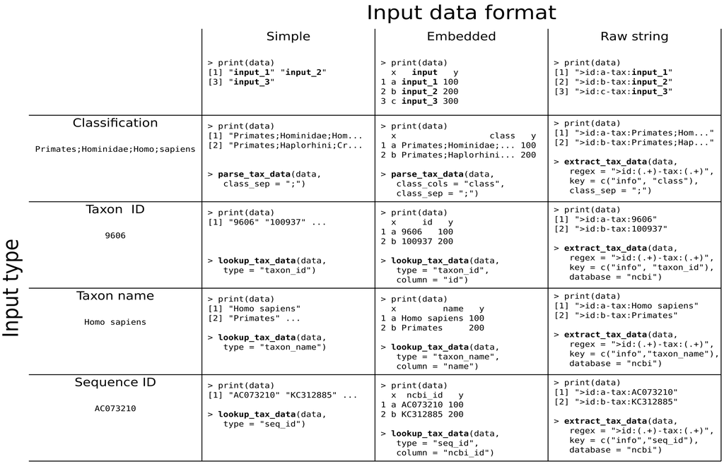

The `parse_tax_data` and `lookup_tax_data` have, in addition to the functionality above, the ability to include additional data sets that are somehow associated with the source datasets (e.g. share a common identifier). Elements in these datasets will be assigned the taxa defined in the source data, so functions like `filter_taxa` and `filter_obs` will work on all of the dataset at once.

## Parsing Hierarchy and hierarchies objects

A set of functions are available for parsing objects of class `Hierarchy` and `hierarchies`. These functions are being ported from the CRAN package `binomen`.

The functions below are “taxonomically aware” so that you can use for example `>` and `<` operators to filter your taxonomic names data.

### pick

`pick()` - Pick out specific taxa, while others are dropped

```r
ex_hierarchy1
```

```
#> <Hierarchy>
#>   no. taxon's:  3
#>   Poaceae / family / 4479
#>   Poa / genus / 4544
#>   Poa annua / species / 93036
```

```r
# specific ranks by rank name
pick(ex_hierarchy1, ranks("family"))
```

```
#> <Hierarchy>
#>   no. taxon's:  1
#>   Poaceae / family / 4479
```

```r
# two elements by taxonomic name
pick(ex_hierarchy1, nms("Poaceae", "Poa"))
```

```
#> <Hierarchy>
#>   no. taxon's:  2
#>   Poaceae / family / 4479
#>   Poa / genus / 4544
```

```r
# two elements by taxonomic identifier
pick(ex_hierarchy1, ids(4479, 4544))
```

```
#> <Hierarchy>
#>   no. taxon's:  2
#>   Poaceae / family / 4479
#>   Poa / genus / 4544
```

```r
# combine types
pick(ex_hierarchy1, ranks("family"), ids(4544))
```

```
#> <Hierarchy>
#>   no. taxon's:  2
#>   Poaceae / family / 4479
#>   Poa / genus / 4544
```

### pop

`pop()` - Pop out taxa, that is, drop them

```r
ex_hierarchy1
```

```
#> <Hierarchy>
#>   no. taxon's:  3
#>   Poaceae / family / 4479
#>   Poa / genus / 4544
#>   Poa annua / species / 93036
```

```r
# specific ranks by rank name
pop(ex_hierarchy1, ranks("family"))
```

```
#> <Hierarchy>
#>   no. taxon's:  2
#>   Poa / genus / 4544
#>   Poa annua / species / 93036
```

```r
# two elements by taxonomic name
pop(ex_hierarchy1, nms("Poaceae", "Poa"))
```

```
#> <Hierarchy>
#>   no. taxon's:  1
#>   Poa annua / species / 93036
```

```r
# two elements by taxonomic identifier
pop(ex_hierarchy1, ids(4479, 4544))
```

```
#> <Hierarchy>
#>   no. taxon's:  1
#>   Poa annua / species / 93036
```

```r
# combine types
pop(ex_hierarchy1, ranks("family"), ids(4544))
```

```
#> <Hierarchy>
#>   no. taxon's:  1
#>   Poa annua / species / 93036
```

### span

`span()` - Select a range of taxa, either by two names, or relational operators

```r
ex_hierarchy1
```

```
#> <Hierarchy>
#>   no. taxon's:  3
#>   Poaceae / family / 4479
#>   Poa / genus / 4544
#>   Poa annua / species / 93036
```

```r
# keep all taxa between family and genus
# - by rank name, taxonomic name or ID
span(ex_hierarchy1, nms("Poaceae", "Poa"))
```

```
#> <Hierarchy>
#>   no. taxon's:  2
#>   Poaceae / family / 4479
#>   Poa / genus / 4544
```

```r
# keep all taxa greater than genus
span(ex_hierarchy1, ranks("> genus"))
```

```
#> <Hierarchy>
#>   no. taxon's:  1
#>   Poaceae / family / 4479
```

```r
# keep all taxa greater than or equal to genus
span(ex_hierarchy1, ranks(">= genus"))
```

```
#> <Hierarchy>
#>   no. taxon's:  2
#>   Poaceae / family / 4479
#>   Poa / genus / 4544
```

```r
# keep all taxa less than Felidae
span(ex_hierarchy2, nms("< Felidae"))
```

```
#> <Hierarchy>
#>   no. taxon's:  2
#>   Puma / genus / 146712
#>   Puma concolor / species / 9696
```

```r
## Multiple operator statements - useful with larger classifications
ex_hierarchy3
```

```
#> <Hierarchy>
#>   no. taxon's:  6
#>   Chordata / phylum / 158852
#>   Vertebrata / subphylum / 331030
#>   Teleostei / class / 161105
#>   Salmonidae / family / 161931
#>   Salmo / genus / 161994
#>   Salmo salar / species / 161996
```

```r
span(ex_hierarchy3, ranks("> genus"), ranks("< phylum"))
```

```
#> <Hierarchy>
#>   no. taxon's:  3
#>   Vertebrata / subphylum / 331030
#>   Teleostei / class / 161105
#>   Salmonidae / family / 161931
```

## For more information

This vignettte is meant to be just an outline of what `taxa` can do. In the future, we plan to release additional, in-depth vignettes for specific topics. More informaiton for specific functions and examples can be found on their man pages by typing the name of the function prefixed by a `?` in an R session. For example, `?filter_taxa` will pull up the help page for `filter_taxa`.